# Importando pacotes

```r
library(tidyverse)
library(summarytools)
```

```r
library(ggplot2)
library(stringr)
```

# Leitura e limpeza dos dados

## Importando o dataset

```r
dados <- read_csv("pokemons2.csv")
```

## Uma visualização superficial dos dados

```r
glimpse(dados)
```

```
## Rows: 1,025
## Columns: 18
## $ index        <dbl> 1, 2, 3, 4, 5, 6, 7, 8, 9, 10, 11, 12, 13, 14, 15, 16, 17…
## $ name         <chr> "bulbasaur", "ivysaur", "venusaur", "charmander", "charme…
## $ rank         <chr> "ordinary", "ordinary", "ordinary", "ordinary", "ordinary…
## $ generation   <chr> "generation-i", "generation-i", "generation-i", "generati…
## $ evolves_from <chr> "nothing", "bulbasaur", "ivysaur", "nothing", "charmander…
## $ type1        <chr> "grass", "grass", "grass", "fire", "fire", "fire", "water…
## $ type2        <chr> "poison", "poison", "poison", "None", "None", "flying", "…
## $ hp           <dbl> 45, 60, 80, 39, 58, 78, 44, 59, 79, 45, 50, 60, 40, 45, 6…
## $ atk          <dbl> 49, 62, 82, 52, 64, 84, 48, 63, 83, 30, 20, 45, 35, 25, 9…
## $ def          <dbl> 49, 63, 83, 43, 58, 78, 65, 80, 100, 35, 55, 50, 30, 50, …
## $ spatk        <dbl> 65, 80, 100, 60, 80, 109, 50, 65, 85, 20, 25, 90, 20, 25,…
## $ spdef        <dbl> 65, 80, 100, 50, 65, 85, 64, 80, 105, 20, 25, 80, 20, 25,…
## $ speed        <dbl> 45, 60, 80, 65, 80, 100, 43, 58, 78, 45, 30, 70, 50, 35, …
## $ total        <dbl> 318, 405, 525, 309, 405, 534, 314, 405, 530, 195, 205, 39…
## $ height       <dbl> 7, 10, 20, 6, 11, 17, 5, 10, 16, 3, 7, 11, 3, 6, 10, 3, 1…
## $ weight       <dbl> 69, 130, 1000, 85, 190, 905, 90, 225, 855, 29, 99, 320, 3…
## $ abilities    <chr> "overgrow chlorophyll", "overgrow chlorophyll", "overgrow…
## $ desc         <chr> "A strange seed was planted on its back at birth. The pla…
```

## Uma sumário rápido do dataset

```r
summarytools::dfSummary(dados)
```

```
## Data Frame Summary
## dados
## Dimensions: 1025 x 18
## Duplicates: 0
##
## ---------------------------------------------------------------------------------------------------------------------
## No   Variable       Stats / Values                  Freqs (% of Valid)     Graph                 Valid      Missing
## ---- -------------- ------------------------------- ---------------------- --------------------- ---------- ---------
## 1    index          Mean (sd) : 513 (296)           1025 distinct values   : : : : : : : : : :   1025       0
##      [numeric]      min < med < max:                                       : : : : : : : : : :   (100.0%)   (0.0%)
##                     1 < 513 < 1025                                         : : : : : : : : : :
##                     IQR (CV) : 512 (0.6)                                   : : : : : : : : : :
##                                                                            : : : : : : : : : :
##
## 2    name           1. abomasnow                       1 ( 0.1%)                                 1025       0
##      [character]    2. abra                            1 ( 0.1%)                                 (100.0%)   (0.0%)
##                     3. absol                           1 ( 0.1%)
##                     4. accelgor                        1 ( 0.1%)
##                     5. aegislash                       1 ( 0.1%)
##                     6. aerodactyl                      1 ( 0.1%)
##                     7. aggron                          1 ( 0.1%)
##                     8. aipom                           1 ( 0.1%)
##                     9. alakazam                        1 ( 0.1%)
##                     10. alcremie                       1 ( 0.1%)
##                     [ 1015 others ]                 1015 (99.0%)           IIIIIIIIIIIIIIIIIII
##
## 3    rank           1. baby                          19 ( 1.9%)                                  1025       0
##      [character]    2. legendary                     70 ( 6.8%)            I                     (100.0%)   (0.0%)
##                     3. mythical                      23 ( 2.2%)
##                     4. ordinary                     913 (89.1%)            IIIIIIIIIIIIIIIII
##
## 4    generation     1. generation-i                 151 (14.7%)            II                    1025       0
##      [character]    2. generation-ii                100 ( 9.8%)            I                     (100.0%)   (0.0%)
##                     3. generation-iii               135 (13.2%)            II
##                     4. generation-iv                107 (10.4%)            II
##                     5. generation-ix                120 (11.7%)            II
##                     6. generation-v                 156 (15.2%)            III
##                     7. generation-vi                 72 ( 7.0%)            I
##                     8. generation-vii                88 ( 8.6%)            I
##                     9. generation-viii               96 ( 9.4%)            I
```

[output cut: 100 more lines]

```
##                     10. big-pecks super-luck riva     3 ( 0.3%)
##                     [ 613 others ]                  947 (92.4%)            IIIIIIIIIIIIIIIIII
##
## 18   desc           1. Not Available                 17 ( 1.7%)                                  1025       0
##      [character]    2. A bird that makes up for       1 ( 0.1%)                                  (100.0%)   (0.0%)
##                     3. A bit of a dandy, it spen      1 ( 0.1%)
##                     4. A body made up of nothing      1 ( 0.1%)
##                     5. A brutal POKéMON with pre      1 ( 0.1%)
##                     6. A carnivorous POKéMON tha      1 ( 0.1%)
##                     7. A clever combatant, this       1 ( 0.1%)
##                     8. A common sight in forests      1 ( 0.1%)
##                     9. A constant collector of i      1 ( 0.1%)
##                     10. A delectable aroma pours      1 ( 0.1%)
##                     [ 999 others ]                  999 (97.5%)            IIIIIIIIIIIIIIIIIII
## ---------------------------------------------------------------------------------------------------------------------
```

- Aqui é importante perceber que, no item 4, a geração 9 foi trocada de lugar com a 5 pois a função dfSummary() organiza por ordem alfabética, com isso, o “ix” que indica 9 em romano, tomou a frente do “v” de todas as gerações de 5 a 8. Isso será corrigido mais a frente

## Checando se há prensença de algum erro ou NA

```r
dados %>%
  summarise(
    across(everything(), ~sum(is.na(.x)))
  )
```

```
## # A tibble: 1 × 18
##   index  name  rank generation evolves_from type1 type2    hp   atk   def spatk
##   <int> <int> <int>      <int>        <int> <int> <int> <int> <int> <int> <int>
## 1     0     0     0          0            0     0     0     0     0     0     0
## # ℹ 7 more variables: spdef <int>, speed <int>, total <int>, height <int>,
## #   weight <int>, abilities <int>, desc <int>
```

- Como pode-se ver, não há valores NA, o que é muito bom, pois essas informações são acessíveis a qualquer um na internet de forma completa e correta (estamos falando da franquia de entretenimento mais rentável do mundo), então ter valores NA seria algo não plausível. Com isso, posso seguir a análise.
- Corrigindo a questão da ordenação das generations citada anteriormente

```r
dados$generation <- str_replace(dados$generation, "generation-", "")
dados$generation <- as.character(as.numeric(as.roman((dados$generation))))
dados[, "generation"]
```

```
## # A tibble: 1,025 × 1
##    generation
##    <chr>
##  1 1
##  2 1
##  3 1
##  4 1
##  5 1
##  6 1
##  7 1
##  8 1
##  9 1
## 10 1
## # ℹ 1,015 more rows
```

- Aqui optei por tirar o texto “generation-” e manter somente os números (continua sendo suficiente para o entendimento), substituino para algarismos árabes.

## Usando mutate para ajustar valores

```r
dados <- dados %>%
  mutate(
    evolves_from = ifelse(evolves_from == "nothing", NA, evolves_from),
    type2 = ifelse(type2 == "None", NA, type2)
  )
```

- Aqui opto por converter os valores “nothing” da coluna “evolves_from” e “None” da coluna “type2” para NA, pois eles indicam a ausência da valor, e é justamente o objetivo do NA em R.

```r
dados <- dados %>%
  mutate(
    weight = weight / 10,
    height = height / 10
  )
```

- Se verificarmos no [site oficial](https://www.pokemon.com/br/pokedex/ivysaur) e compararmos com a saída de dfSummary(), perceberemos que os pesos e as alturas estão com uma espécie de erro, parece que estão multiplicados por 10.
- O bloco acima resolve o problema
- Com isso, a leitura e limpeza dos dados foi feita e podemos partir para o próximo passo.

# Análise exploratória

## Verificando quantidade de valores diferentes em colunas de interesse

- Apesar disso ser verificável na saída de dfSummary(), vale ressaltar a quantidade de valores únicos de algumas colunas, pois com isso, podemos tomar dimensão da variedade de informações presentes no dataset.
- Escolhi as seguintes colunas: “rank”, “generation”, “evolves_from”, “type1”, “type2” e “abilities.” Com elas, conseguimos entender um pouco melhor de como funciona a divisão e organização dos Pokémons.

### Coluna “rank”

```r
dados %>%
  summarise(count = n_distinct(rank))
```

```
## # A tibble: 1 × 1
##   count
##   <int>
## 1     4
```

- Temos somente 4 ranques de Pokémon

### Coluna “generation”

```r
dados %>%
  summarise(count = n_distinct(generation))
```

```
## # A tibble: 1 × 1
##   count
##   <int>
## 1     9
```

- São 9 gerações de Pokémon até agora (podem lançar mais no futuro)

### Coluna “evolves_from”

```r
dados %>%
  summarise(count = n_distinct(evolves_from))
```

```
## # A tibble: 1 × 1
##   count
##   <int>
## 1   458
```

### Coluna “type1”

```r
dados %>%
  summarise(count = n_distinct(type1))
```

```
## # A tibble: 1 × 1
##   count
##   <int>
## 1    18
```

- São 18 tipos primários

### Coluna “type2”

```r
dados %>%
  summarise(count = n_distinct(type2))
```

```
## # A tibble: 1 × 1
##   count
##   <int>
## 1    19
```

- São 19 tipos secundários (os mesmos 18 primários + NA)

### Coluna “abilities”

```r
dados %>%
  summarise(count = n_distinct(abilities))
```

```
## # A tibble: 1 × 1
##   count
##   <int>
## 1   623
```

- Importante perceber que, nem todos os Pokémons apresentam somente 1 habilidade. Na saída de dfSummary percebe-se que, algumas ocorrências de abilities tem 2 ou mais valores agregados, separados por um espaço no texto. Como no item 9 da lista 17 (lista de “abilities”), ali são 3 habilidades, o Pokémon assume 1 delas somente, quando nasce. Com isso, o trabalho de identificar as habilidades fica dificultado, uma vez que, o delimitador entre uma habilidade e outra é um espaço, que também pode fazer parte do nome de uma habilidade.

## Verificando quantidade de valores NA em colunas de interesse

### Coluna “rank”

```r
sum(is.na(dados$rank))
```

```
## [1] 0
```

### Coluna “generation”

```r
sum(is.na(dados$generation))
```

```
## [1] 0
```

### Coluna “evolves_from”

```r
sum(is.na(dados$evolves_from))
```

```
## [1] 541
```

- Aqui vemos o efeito de ter realizado a operação de trocar o valor “nothing” por NA

### Coluna “type1”

```r
sum(is.na(dados$type1))
```

```
## [1] 0
```

### Coluna “type2”

```r
sum(is.na(dados$type2))
```

```
## [1] 499
```

- Aqui vemos o efeito de ter realizado a operação de trocar o valor “None” por NA

### Coluna “abilities”

```r
sum(is.na(dados$abilities))
```

```
## [1] 0
```

## Agregando os dados e gerando estatísticas

- Nesse tópico, farei um estudo focado em entender as diferenças entre os Pokémons conforme a variação de seus ranques (“baby”, “legendary”, “mythical”, “ordinary”). Com base nos jogos e animes, sabemos que os míticos e lendários são Pokémons especiais, pois aparecem pouquíssimas vezes, entre outras características únicas. Porém, não sabemos o quão bem conseguimos diferenciar esses ranques somente com as informações do dataset. O objetivo do estudo é de verificar isso.

### Tipagens dos Pokémons

- Vamos agrupar os tipos e os ranques para entender se existe algum padrão entre essas classificações

#### Ranque x tipo primário

```r
dados %>%
  group_by(rank, type1) %>%
  summarise(count = n())
```

```
## # A tibble: 57 × 3
## # Groups:   rank [4]
##    rank  type1    count
##    <chr> <chr>    <int>
##  1 baby  electric     3
##  2 baby  fairy        2
##  3 baby  fighting     2
##  4 baby  fire         1
##  5 baby  grass        1
##  6 baby  ice          1
##  7 baby  normal       4
##  8 baby  psychic      3
##  9 baby  rock         1
## 10 baby  water        1
## # ℹ 47 more rows
```

- Em proporção

```r
dados %>%
  group_by(rank, type1) %>%
  summarise(count = n()) %>%
  group_by(rank) %>%
  mutate(percentage = count / sum(count) * 100)
```

```
## # A tibble: 57 × 4
## # Groups:   rank [4]
##    rank  type1    count percentage
##    <chr> <chr>    <int>      <dbl>
##  1 baby  electric     3      15.8
##  2 baby  fairy        2      10.5
##  3 baby  fighting     2      10.5
##  4 baby  fire         1       5.26
##  5 baby  grass        1       5.26
##  6 baby  ice          1       5.26
##  7 baby  normal       4      21.1
##  8 baby  psychic      3      15.8
##  9 baby  rock         1       5.26
## 10 baby  water        1       5.26
## # ℹ 47 more rows
```

- Lembrando que a porcentagem diz respeito a concentração de ocorrência do tipo primário dentro do ranque

#### Ranque x tipo secundário

```r
dados %>%
  group_by(rank, type2) %>%
  summarise(count = n())
```

```
## # A tibble: 47 × 3
## # Groups:   rank [4]
##    rank      type2    count
##    <chr>     <chr>    <int>
##  1 baby      fairy        3
##  2 baby      flying       1
##  3 baby      poison       2
##  4 baby      psychic      1
##  5 baby      <NA>        12
##  6 legendary dark         1
##  7 legendary dragon       6
##  8 legendary electric     1
##  9 legendary fairy        5
## 10 legendary fighting     4
## # ℹ 37 more rows
```

- Em proporção

```r
dados %>%
  group_by(rank, type2) %>%
  summarise(count = n()) %>%
  group_by(rank) %>%
  mutate(percentage = count / sum(count) * 100)
```

```
## # A tibble: 47 × 4
## # Groups:   rank [4]
##    rank      type2    count percentage
##    <chr>     <chr>    <int>      <dbl>
##  1 baby      fairy        3      15.8
##  2 baby      flying       1       5.26
##  3 baby      poison       2      10.5
##  4 baby      psychic      1       5.26
##  5 baby      <NA>        12      63.2
##  6 legendary dark         1       1.43
##  7 legendary dragon       6       8.57
##  8 legendary electric     1       1.43
##  9 legendary fairy        5       7.14
## 10 legendary fighting     4       5.71
## # ℹ 37 more rows
```

- Quantos em cada ranque tem tipo secundário?

```r
dados %>%
  filter(!is.na(type2)) %>%
  group_by(rank) %>%
  summarise(count = n())
```

```
## # A tibble: 4 × 2
##   rank      count
##   <chr>     <int>
## 1 baby          7
## 2 legendary    41
## 3 mythical     13
## 4 ordinary    465
```

- Em proporção

```r
dados %>%
  group_by(rank) %>%
  summarise(media = mean(!is.na(type2)) * 100)
```

```
## # A tibble: 4 × 2
##   rank      media
##   <chr>     <dbl>
## 1 baby       36.8
## 2 legendary  58.6
## 3 mythical   56.5
## 4 ordinary   50.9
```

- Aqui já vemos que não é tão comum para os do ranque “baby” terem tipo secundário, diferente dos demais

## Visualização

### Scatter plots

- Qual é a relação entre o peso e a vida?

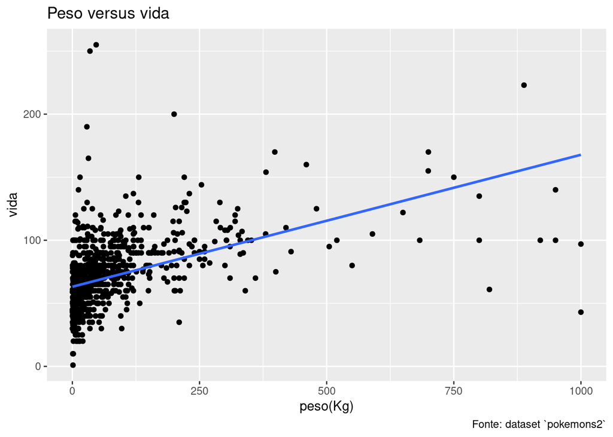

```r
dados %>%
  ggplot(aes(x = weight, y = hp)) +
  geom_point() +
  geom_smooth(
    aes(group = 1),
    show.legend = FALSE,
    method = 'lm',
    se = FALSE,
    linewidth = 1
  ) +
  labs(
    title = 'Peso versus vida',
    caption = 'Fonte: dataset `pokemons2`',
    x = 'peso(Kg)',
    y = 'vida'
  )
```

- Pela reta de regressão conseguimos ver que existe uma relação de proporcionalidade, onde quanto maior o peso, maior a vida.
- E qual é a relação entre a altura e a vida?

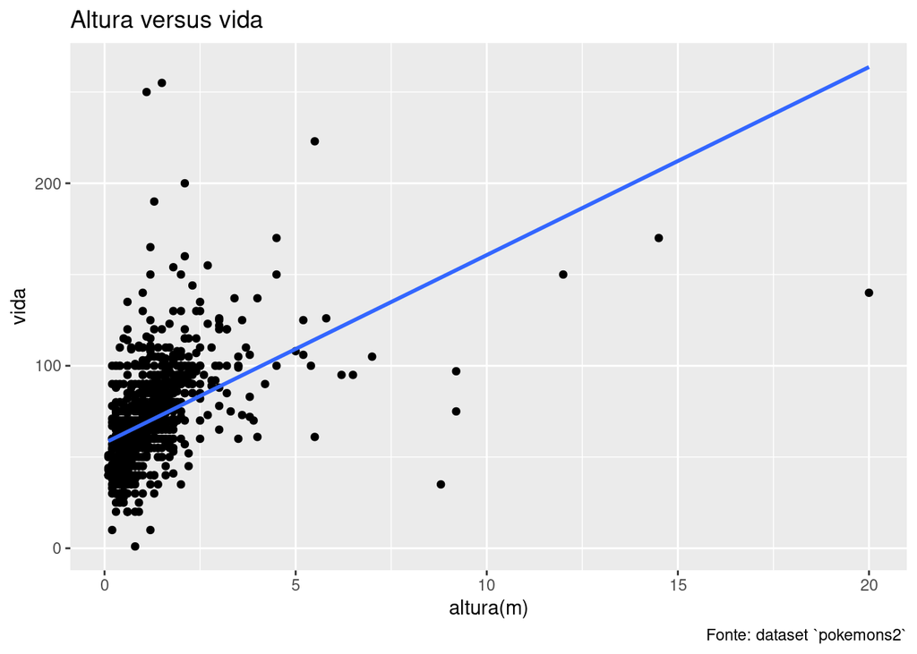

```r
dados %>%
  ggplot(aes(x = height, y = hp)) +
  geom_point() +
  geom_smooth(
    aes(group = 1),
    show.legend = FALSE,
    method = 'lm',
    se = FALSE,
    linewidth = 1
  ) +
  labs(
    title = 'Altura versus vida',
    caption = 'Fonte: dataset `pokemons2`',
    x = 'altura(m)',
    y = 'vida'
  )
```

- Aqui vemos que essa proporção já é mais acentuada: com pouco crescimento da altura, a vida aumenta mais do que comparado ao peso, dado a inclinação da reta de regressão.

### Histogramas

#### Distribuição das estatísticas

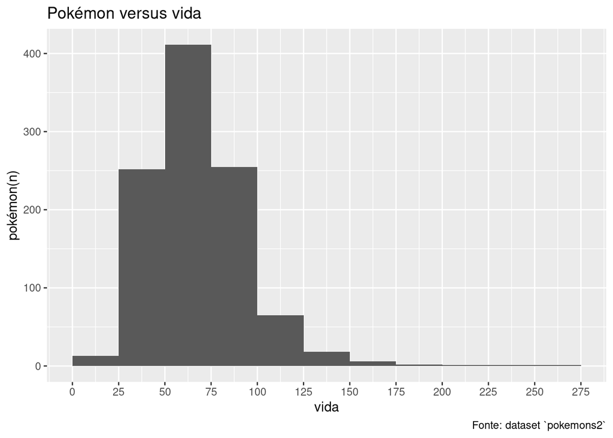

```r
dados %>%
  ggplot(aes(x = hp)) +
    geom_histogram(breaks = seq(0, 275, 25)) +
    scale_x_continuous(breaks = seq(0, 275, 25)) +
  labs(
    title = 'Pokémon versus vida',
    caption = 'Fonte: dataset `pokemons2`',
    x = 'vida',
    y = 'pokémon(n)'
  )
```

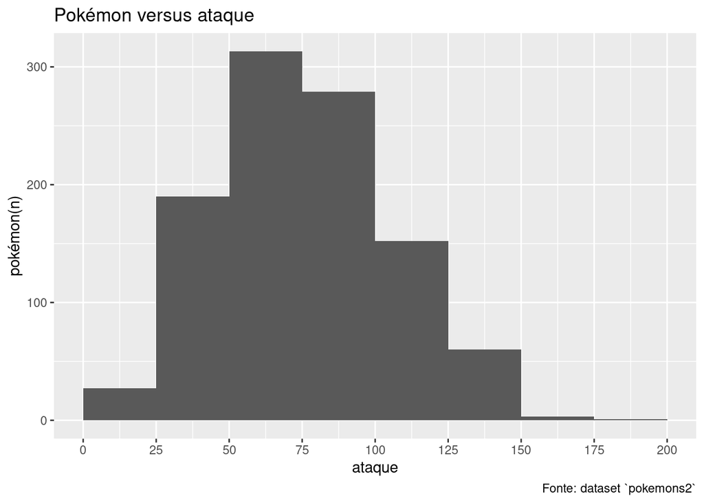

```r
dados %>%
  ggplot(aes(x = atk)) +
    geom_histogram(breaks = seq(0, 200, 25)) +
    scale_x_continuous(breaks = seq(0, 200, 25)) +
  labs(
    title = 'Pokémon versus ataque',
    caption = 'Fonte: dataset `pokemons2`',
    x = 'ataque',
    y = 'pokémon(n)'
  )
```

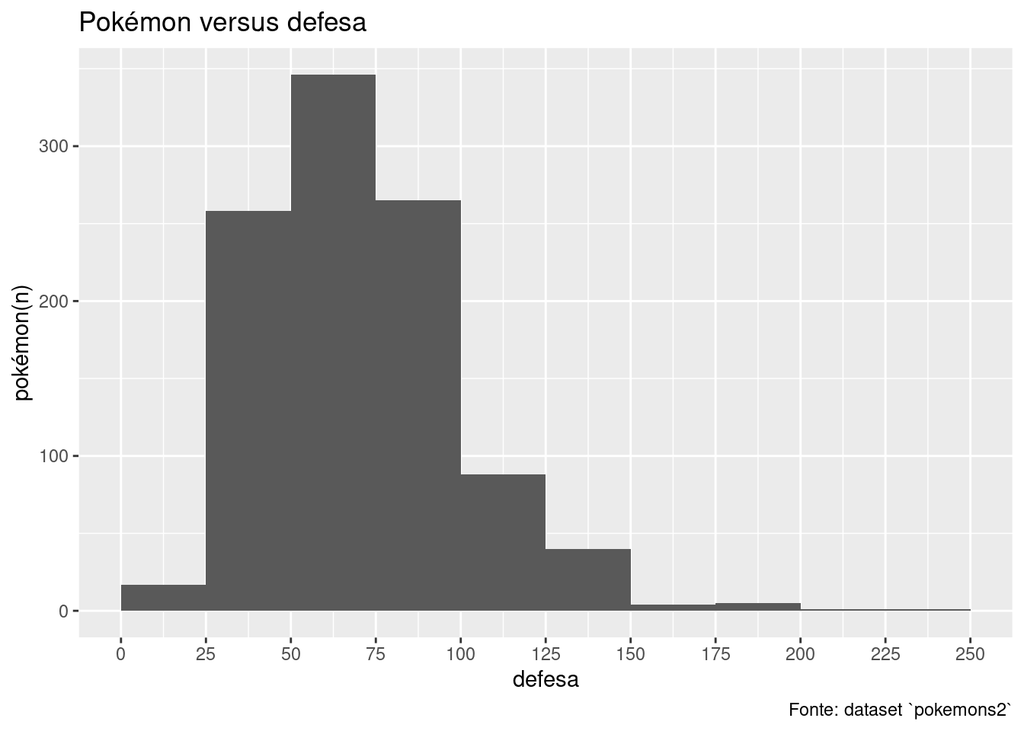

```r
dados %>%
  ggplot(aes(x = def)) +
    geom_histogram(breaks = seq(0, 250, 25)) +
    scale_x_continuous(breaks = seq(0, 250, 25)) +
  labs(
    title = 'Pokémon versus defesa',
    caption = 'Fonte: dataset `pokemons2`',
    x = 'defesa',
    y = 'pokémon(n)'
  )
```

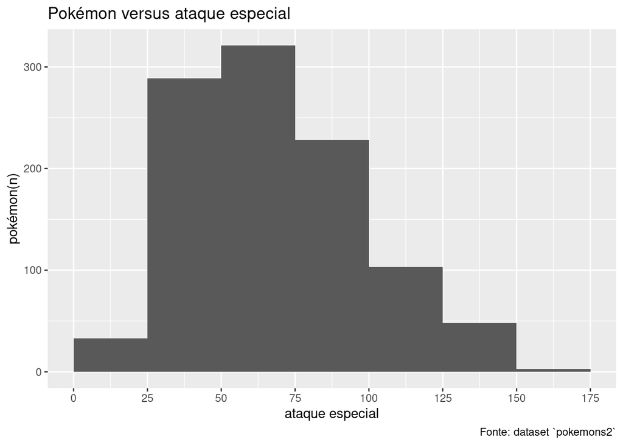

```r
dados %>%
  ggplot(aes(x = spatk)) +
    geom_histogram(breaks = seq(0, 175, 25)) +
    scale_x_continuous(breaks = seq(0, 175, 25)) +
  labs(
    title = 'Pokémon versus ataque especial',
    caption = 'Fonte: dataset `pokemons2`',
    x = 'ataque especial',
    y = 'pokémon(n)'
  )
```

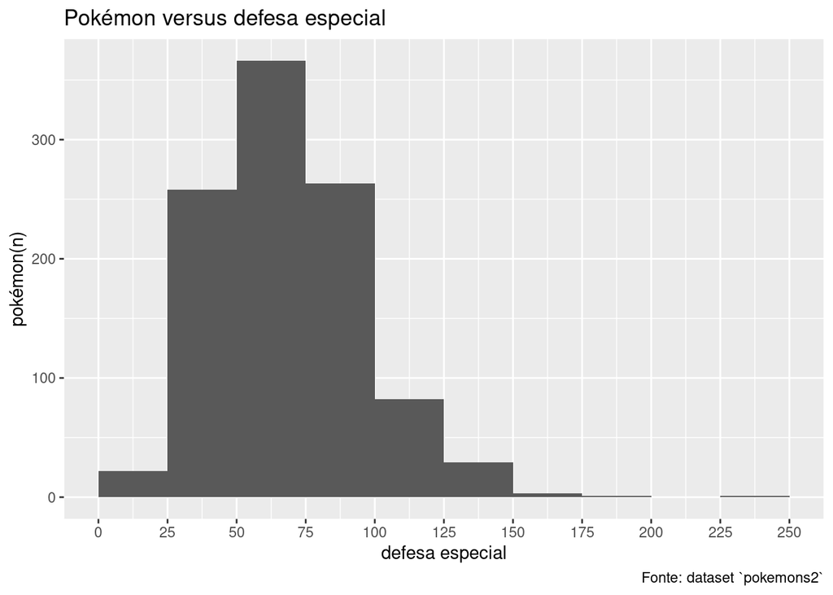

```r
dados %>%
  ggplot(aes(x = spdef)) +
    geom_histogram(breaks = seq(0, 250, 25)) +
    scale_x_continuous(breaks = seq(0, 250, 25)) +
  labs(
    title = 'Pokémon versus defesa especial',
    caption = 'Fonte: dataset `pokemons2`',
    x = 'defesa especial',
    y = 'pokémon(n)'
  )
```

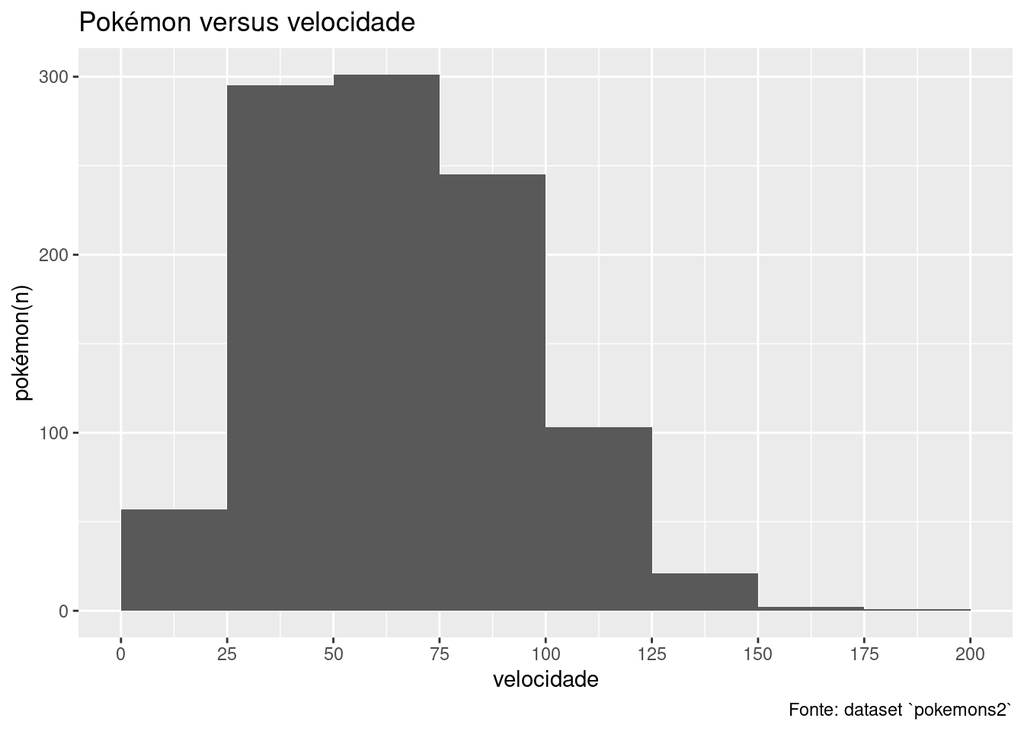

```r
dados %>%
  ggplot(aes(x = speed)) +
    geom_histogram(breaks = seq(0, 200, 25)) +
    scale_x_continuous(breaks = seq(0, 200, 25)) +
  labs(
    title = 'Pokémon versus velocidade',
    caption = 'Fonte: dataset `pokemons2`',
    x = 'velocidade',
    y = 'pokémon(n)'
  )
```

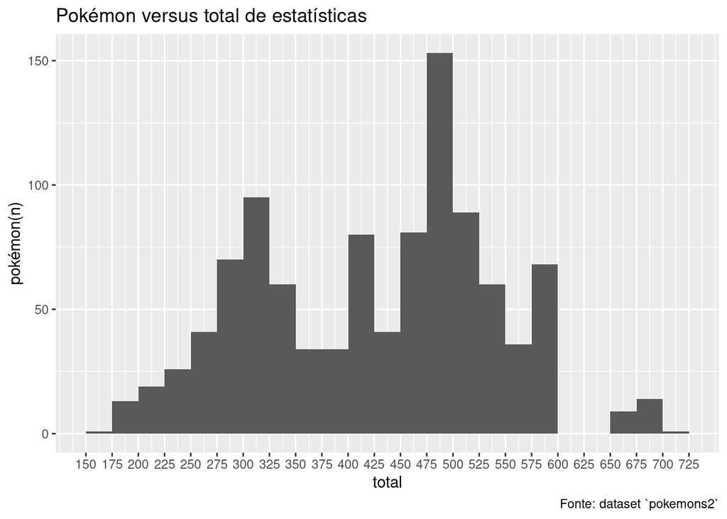

```r
dados %>%
  ggplot(aes(x = total)) +
    geom_histogram(breaks = seq(150, 725, 25)) +
    scale_x_continuous(breaks = seq(150, 725, 25)) +
  labs(
    title = 'Pokémon versus total de estatísticas',
    caption = 'Fonte: dataset `pokemons2`',
    x = 'total',
    y = 'pokémon(n)'
  )
```

- Em geral, os Pokémons são bem equilibrados (no sentido de que existe uma boa distribuição pelas categorias criadas nos histogramas)

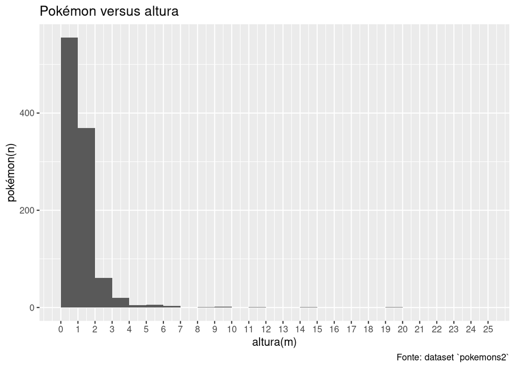

```r
dados %>%
  ggplot(aes(x = height)) +
    geom_histogram(breaks = seq(0, 25, 1)) +
    scale_x_continuous(breaks = seq(0, 25, 1)) +
  labs(
    title = 'Pokémon versus altura',
    caption = 'Fonte: dataset `pokemons2`',
    x = 'altura(m)',
    y = 'pokémon(n)'
  )
```

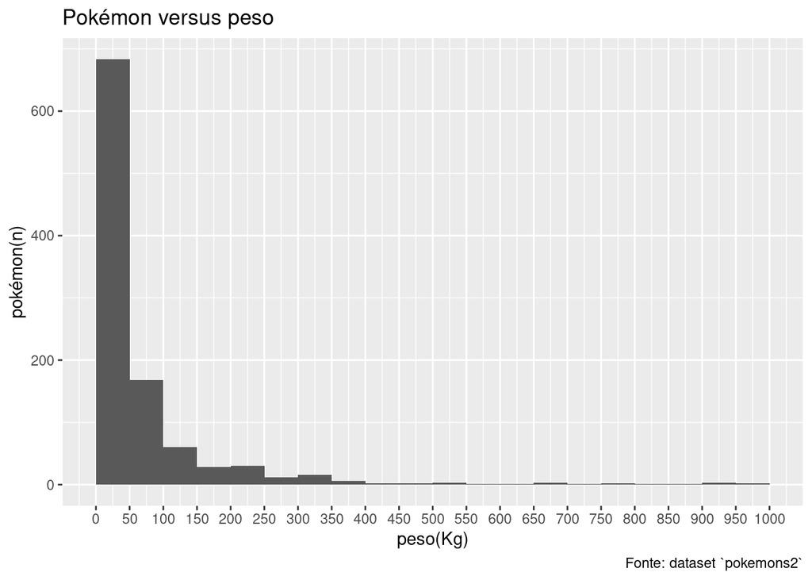

```r
dados %>%
  ggplot(aes(x = weight)) +
    geom_histogram(breaks = seq(0, 1000, 50)) +
    scale_x_continuous(breaks = seq(0, 1000, 50)) +
  labs(
    title = 'Pokémon versus peso',
    caption = 'Fonte: dataset `pokemons2`',
    x = 'peso(Kg)',
    y = 'pokémon(n)'
  )
```

- Percebe-se que há uma grande concentração de Pokémons nos menores intervalos de altura e peso

### Boxplots

#### Estatísticas dos Pokémons

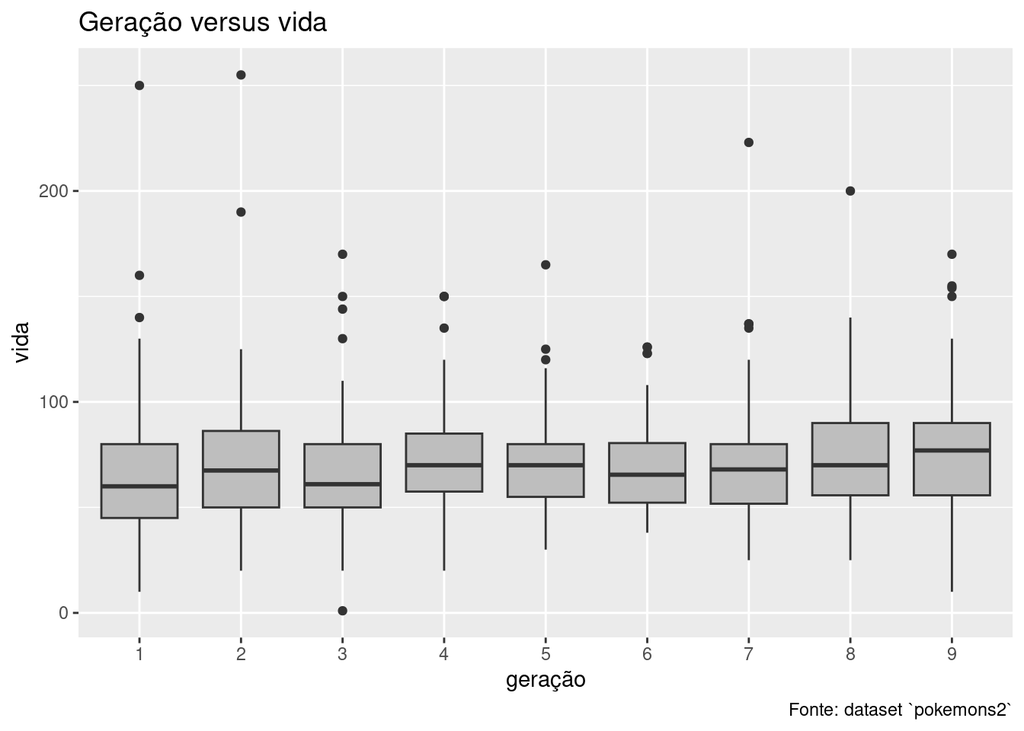

```r
dados %>%
  ggplot(aes(x = generation, y = hp)) +
    geom_boxplot(fill = 'gray') +
  labs(
    title = 'Geração versus vida',
    caption = 'Fonte: dataset `pokemons2`',
    x = 'geração',
    y = 'vida'
  )
```

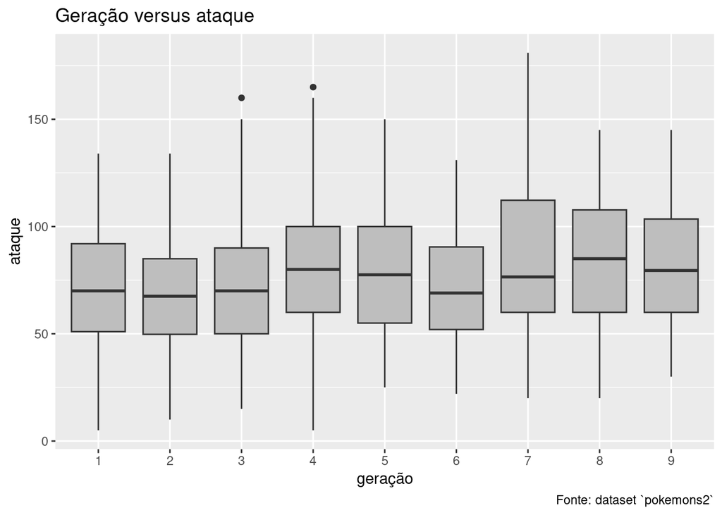

```r
dados %>%
  ggplot(aes(x = generation, y = atk)) +
    geom_boxplot(fill = 'gray') +
  labs(
    title = 'Geração versus ataque',
    caption = 'Fonte: dataset `pokemons2`',
    x = 'geração',
    y = 'ataque'
  )
```

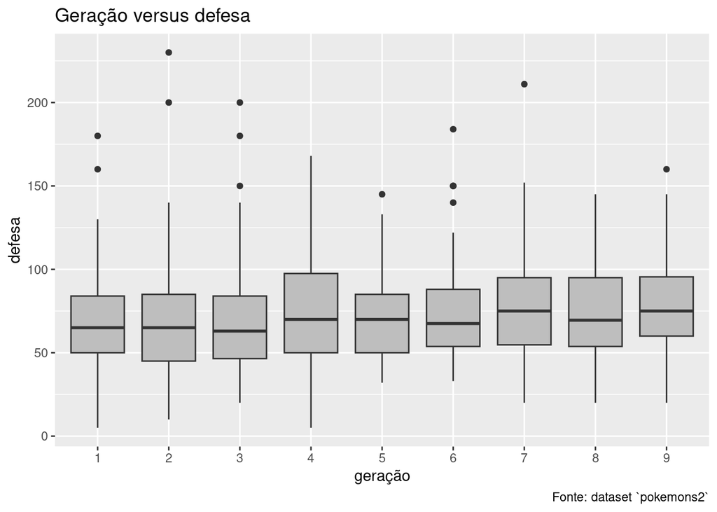

```r
dados %>%
  ggplot(aes(x = generation, y = def)) +
    geom_boxplot(fill = 'gray') +
  labs(
    title = 'Geração versus defesa',
    caption = 'Fonte: dataset `pokemons2`',
    x = 'geração',
    y = 'defesa'
  )
```

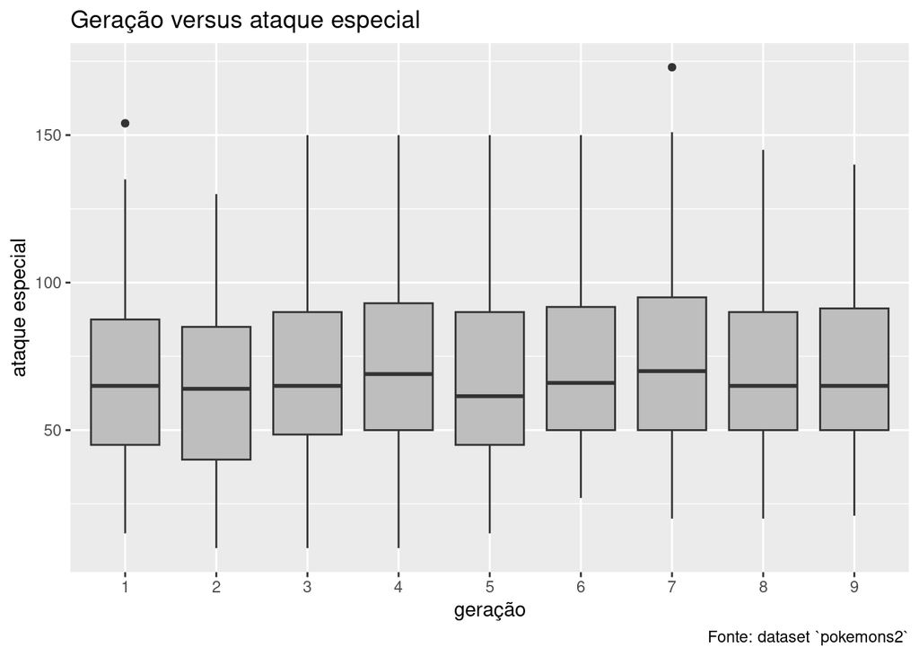

```r
dados %>%
  ggplot(aes(x = generation, y = spatk)) +
    geom_boxplot(fill = 'gray') +
  labs(
    title = 'Geração versus ataque especial',
    caption = 'Fonte: dataset `pokemons2`',
    x = 'geração',
    y = 'ataque especial'
  )
```

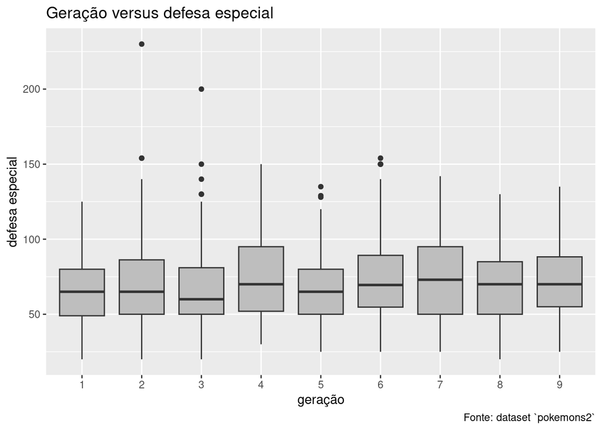

```r
dados %>%
  ggplot(aes(x = generation, y = spdef)) +
    geom_boxplot(fill = 'gray') +
  labs(
    title = 'Geração versus defesa especial',
    caption = 'Fonte: dataset `pokemons2`',
    x = 'geração',
    y = 'defesa especial'
  )
```

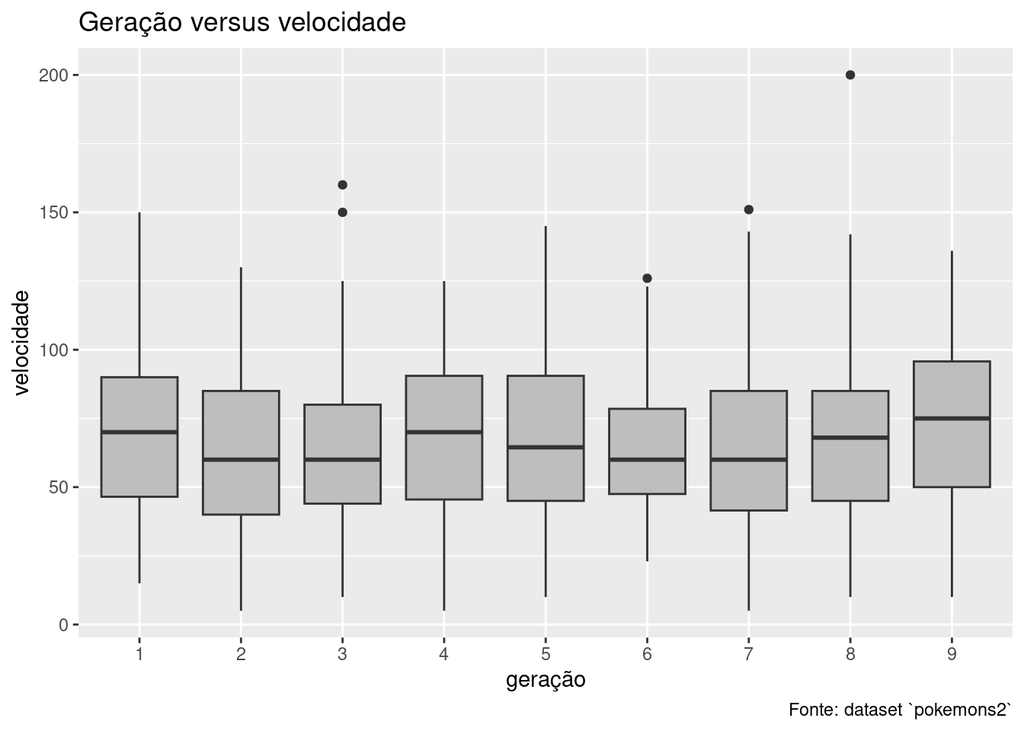

```r
dados %>%
  ggplot(aes(x = generation, y = speed)) +
    geom_boxplot(fill = 'gray') +
  labs(
    title = 'Geração versus velocidade',
    caption = 'Fonte: dataset `pokemons2`',
    x = 'geração',
    y = 'velocidade'
  )
```

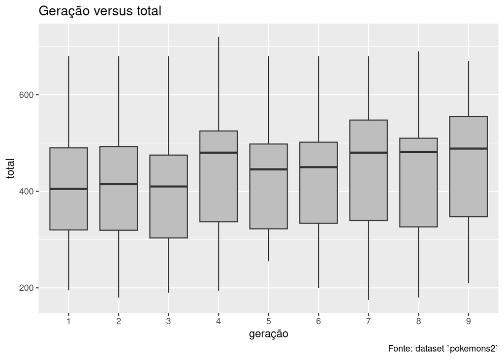

```r
dados %>%
  ggplot(aes(x = generation, y = total)) +
    geom_boxplot(fill = 'gray') +
  labs(
    title = 'Geração versus total',
    caption = 'Fonte: dataset `pokemons2`',
    x = 'geração',
    y = 'total'
  )
```

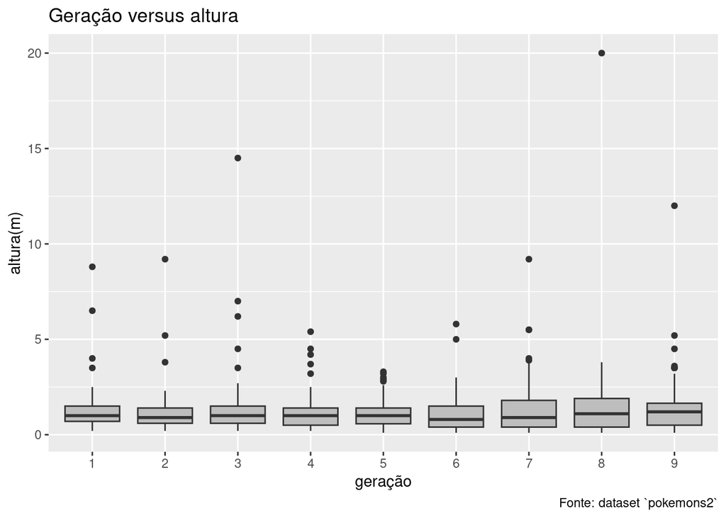

```r
dados %>%
  ggplot(aes(x = generation, y = height)) +
    geom_boxplot(fill = 'gray') +
  labs(
    title = 'Geração versus altura',
    caption = 'Fonte: dataset `pokemons2`',
    x = 'geração',
    y = 'altura(m)'
  )
```

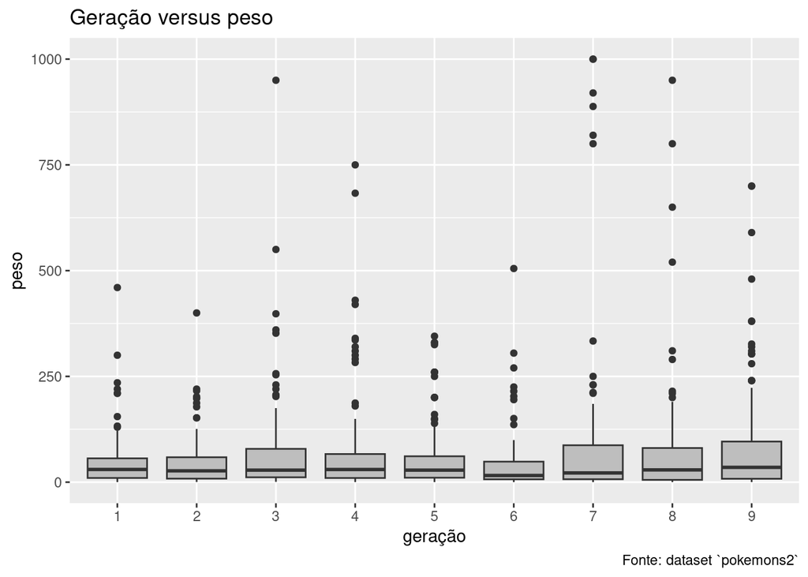

```r
dados %>%
  ggplot(aes(x = generation, y = weight)) +
    geom_boxplot(fill = 'gray') +
  labs(
    title = 'Geração versus peso',
    caption = 'Fonte: dataset `pokemons2`',
    x = 'geração',
    y = 'peso'
  )
```

- Com esses gráficos, conseguimos ver que, considerando que os círculos são outliers, existem consideráveis ocorrências de outliers em cada estatística, exceto uma: “total”.
- Provavelmente, esse deve ser um parâmetro muito importante para os desenvolvedores do jogo, se não o mais. Pode-se constatar que, é plausível um Pokémon ser um outlier em uma estatística ou outra, mas no total, ele tem que ficar dentro de um intervalo definido. Isso que possibilita a dualidade entre balanceamento e variedade na mecânica do jogo. Se todos os Pokémons fossem mais ou menos os mesmos (em relação as estatísticas), não teria como fazer diversas combinações táticas, tirando a diversão. Ao mesmo tempo, se existissem outliers na estatística “total”, provavelmente seriam desbalanceados, e perejudicariam a experiência.

### Barras e colunas

#### Quantidade de Pokémons e seus ranques ao longo das gerações

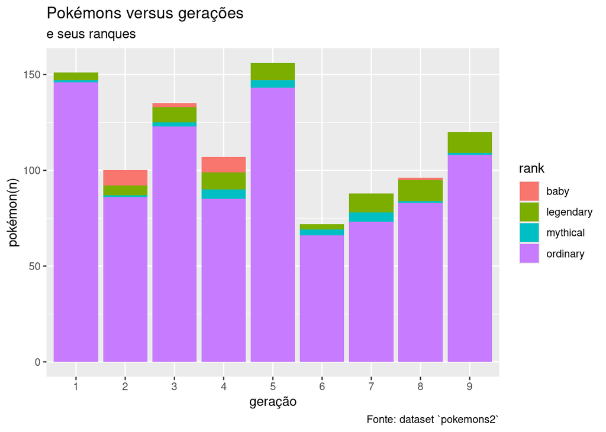

```r
dados %>%
  ggplot(aes(x = generation, fill = rank)) +
    geom_bar() +
    labs(
    title = 'Pokémons versus gerações',
    subtitle = 'e seus ranques',
    caption = 'Fonte: dataset `pokemons2`',
    x = 'geração',
    y = 'pokémon(n)'
  )
```

- Acho interessante percebermos algumas coisas aqui:
- Claramente, houverem menos Pokémons do que o normal na sexta geração. Isso não é atoa. Houve uma troca de plataforma entre a geração 5 e a 6 (Nintendo DS para Nintendo 3DS), o que com certeza gerou uma carga maior de trabalho para os desenvolvedores. Implementar novos recursos e um novo hardware não é algo que seja fácil de fazer em uma aplicação gráfica de tempo real como um jogo. Além disso, novas mecânicas foram introduzidas, como a Mega Evolução, o que incentivou os desenvolvedores a trazerem de volta alguns Pokémons antigos, apelando para a nostalgia do público que cresceu jogando Pokémon, dando uma margem de segurança a mais dentro de uma abordagem arriscada.

### Gráficos de linha

#### Quantidade de Pokémons por tipo, por geração

- Aqui vou escolher alguns tipos primários específicos para analisar a quantidade de Pokémons desse tipo adicionados em cada geração
- Os tipos são: “dragon”, “ice”, “psychic” e “ground”

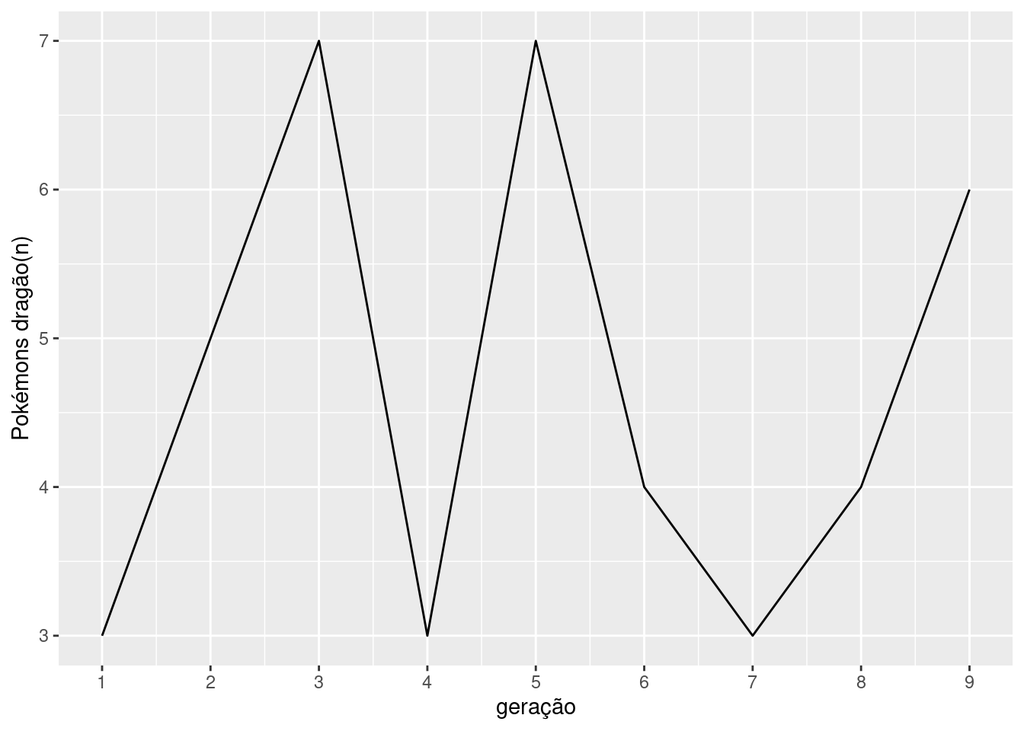

```r
dados %>%
filter(type1 == "dragon") %>%
group_by(generation) %>%
summarise(ocorrencias = n()) %>%
ggplot(aes(x = as.numeric(generation), y = ocorrencias)) +
scale_x_continuous(breaks = 1:9) +
geom_line() +
labs(x = "geração", y = "Pokémons dragão(n)")
```

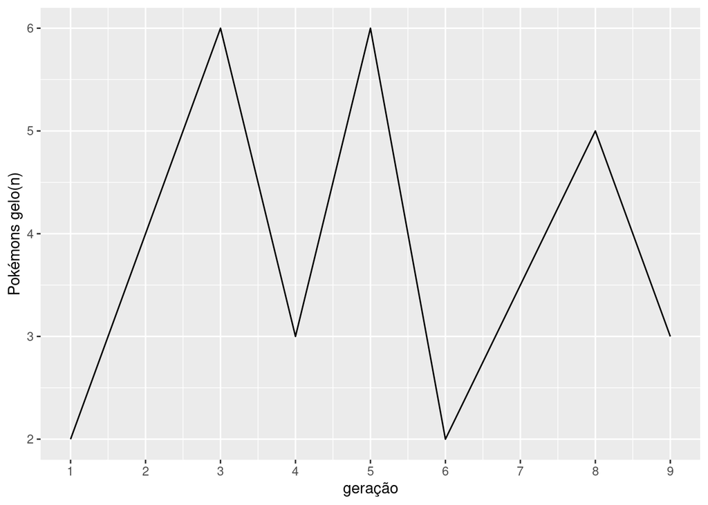

```r
dados %>%
filter(type1 == "ice") %>%
group_by(generation) %>%
summarise(ocorrencias = n()) %>%
ggplot(aes(x = as.numeric(generation), y = ocorrencias))  +
scale_x_continuous(breaks = 1:9) +
geom_line() +
labs(x = "geração", y = "Pokémons gelo(n)")
```

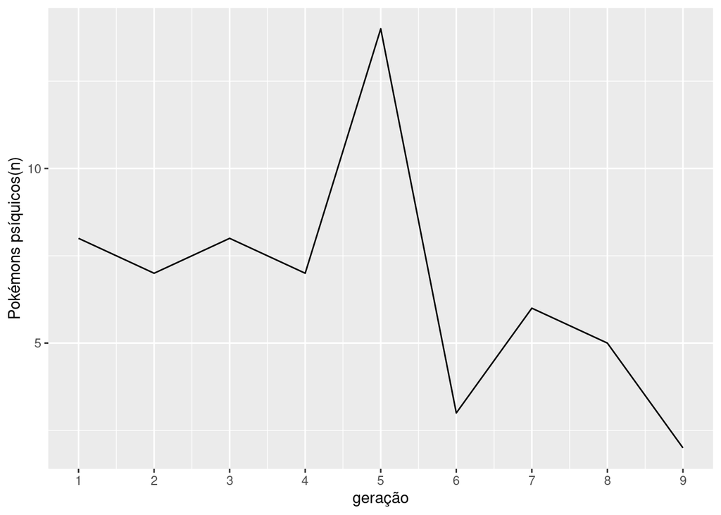

```r
dados %>%
filter(type1 == "psychic") %>%
group_by(generation) %>%
summarise(ocorrencias = n()) %>%
ggplot(aes(x = as.numeric(generation), y = ocorrencias))  +
scale_x_continuous(breaks = 1:9) +
geom_line() +
labs(x = "geração", y = "Pokémons psíquicos(n)")
```

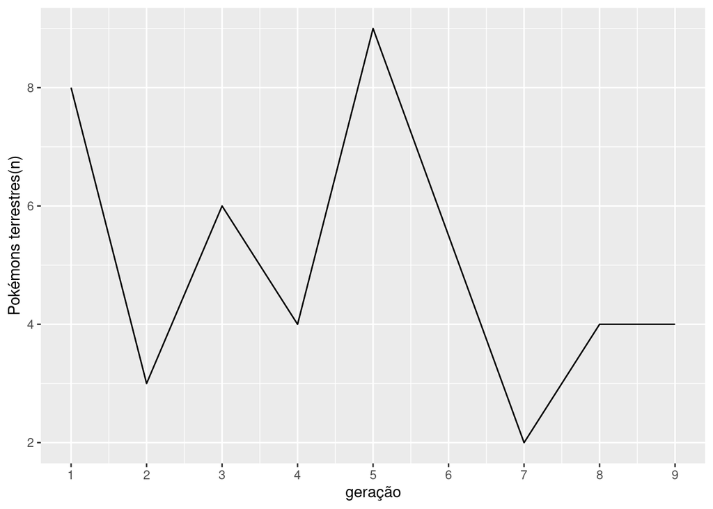

```r
dados %>%
filter(type1 == "ground") %>%
group_by(generation) %>%
summarise(ocorrencias = n()) %>%
ggplot(aes(x = as.numeric(generation), y = ocorrencias))  +
scale_x_continuous(breaks = 1:9) +
geom_line() +
labs(x = "geração", y = "Pokémons terrestres(n)")
```